# Udacity - Project 2

## Data Set Selected - TMDB Movies Dataset

>

## Questions Asked

>

> 1. Which genres are most popular from year to year?
> 2. What kinds of properties are associated with movies that have high revenues?
> 3. What is the impact of runtime on popularity?

```python
# importing pandas and reading csv file

import pandas as pd

mov_df = pd.read_csv('/Users/amsahni/Anaconda3/Udacity-Investigate_A_Dataset/tmdb-movies.csv')
```

```python
# Looking range of movie release_date

z = set(mov_df.release_year)
```

## Data Wrangling

### General Properties

```python
# looking for total rows, columns, datatype of the the columns

mov_df.info()
```

```
<class 'pandas.core.frame.DataFrame'>
RangeIndex: 10866 entries, 0 to 10865
Data columns (total 21 columns):
 #   Column                Non-Null Count  Dtype
---  ------                --------------  -----
 0   id                    10866 non-null  int64
 1   imdb_id               10856 non-null  object
 2   popularity            10866 non-null  float64
 3   budget                10866 non-null  int64
 4   revenue               10866 non-null  int64
 5   original_title        10866 non-null  object
 6   cast                  10790 non-null  object
 7   homepage              2936 non-null   object
 8   director              10822 non-null  object
 9   tagline               8042 non-null   object
 10  keywords              9373 non-null   object
 11  overview              10862 non-null  object
 12  runtime               10866 non-null  int64
 13  genres                10843 non-null  object
 14  production_companies  9836 non-null   object
 15  release_date          10866 non-null  object
 16  vote_count            10866 non-null  int64
 17  vote_average          10866 non-null  float64
 18  release_year          10866 non-null  int64
 19  budget_adj            10866 non-null  float64
 20  revenue_adj           10866 non-null  float64
dtypes: float64(4), int64(6), object(11)
memory usage: 1.7+ MB
```

```python
# looking for general stats for the data set

mov_df.describe()
```

|  | id | popularity | budget | revenue | runtime | vote_count | vote_average | release_year | budget_adj | revenue_adj |
| --- | --- | --- | --- | --- | --- | --- | --- | --- | --- | --- |
| count | 10866.000000 | 10866.000000 | 1.086600e+04 | 1.086600e+04 | 10866.000000 | 10866.000000 | 10866.000000 | 10866.000000 | 1.086600e+04 | 1.086600e+04 |
| mean | 66064.177434 | 0.646441 | 1.462570e+07 | 3.982332e+07 | 102.070863 | 217.389748 | 5.974922 | 2001.322658 | 1.755104e+07 | 5.136436e+07 |
| std | 92130.136561 | 1.000185 | 3.091321e+07 | 1.170035e+08 | 31.381405 | 575.619058 | 0.935142 | 12.812941 | 3.430616e+07 | 1.446325e+08 |
| min | 5.000000 | 0.000065 | 0.000000e+00 | 0.000000e+00 | 0.000000 | 10.000000 | 1.500000 | 1960.000000 | 0.000000e+00 | 0.000000e+00 |
| 25% | 10596.250000 | 0.207583 | 0.000000e+00 | 0.000000e+00 | 90.000000 | 17.000000 | 5.400000 | 1995.000000 | 0.000000e+00 | 0.000000e+00 |
| 50% | 20669.000000 | 0.383856 | 0.000000e+00 | 0.000000e+00 | 99.000000 | 38.000000 | 6.000000 | 2006.000000 | 0.000000e+00 | 0.000000e+00 |
| 75% | 75610.000000 | 0.713817 | 1.500000e+07 | 2.400000e+07 | 111.000000 | 145.750000 | 6.600000 | 2011.000000 | 2.085325e+07 | 3.369710e+07 |
| max | 417859.000000 | 32.985763 | 4.250000e+08 | 2.781506e+09 | 900.000000 | 9767.000000 | 9.200000 | 2015.000000 | 4.250000e+08 | 2.827124e+09 |

```python
# total null values in the data set

mov_df.isna().sum()
```

```
id                         0
imdb_id                   10
popularity                 0
budget                     0
revenue                    0
original_title             0
cast                      76
homepage                7930
director                  44
tagline                 2824
keywords                1493
overview                   4
runtime                    0
genres                    23
production_companies    1030
release_date               0
vote_count                 0
vote_average               0
release_year               0
budget_adj                 0
revenue_adj                0
dtype: int64
```

```python
# looking for duplicates in the data set

mov_df.duplicated().sum()
```

```
1
```

```python
# looking for unique values in the columns for the data set

mov_df.nunique()
```

```
id                      10865
imdb_id                 10855
popularity              10814
budget                    557
revenue                  4702
original_title          10571
cast                    10719
homepage                 2896
director                 5067
tagline                  7997
keywords                 8804
overview                10847
runtime                   247
genres                   2039
production_companies     7445
release_date             5909
vote_count               1289
vote_average               72
release_year               56
budget_adj               2614
revenue_adj              4840
dtype: int64
```

## Data Cleaning

### Dropping Columns which are not required in the Analysis (Not required for the questions asked)

> 1. imdb_id
> 2. homepage
> 3. director
> 4. tagline
> 5. keywords
> 6. overview
> 7. production_companies
> 8. cast

```python
# Dropping Columns which are not required for the analysis\

mov_df.drop(['imdb_id','homepage','director','tagline','overview','production_companies', 'keywords', 'cast'], axis = 1, inplace=True)
```

```python
# confirming the dropped columns

mov_df.info()
```

```
<class 'pandas.core.frame.DataFrame'>
RangeIndex: 10866 entries, 0 to 10865
Data columns (total 13 columns):
 #   Column          Non-Null Count  Dtype
---  ------          --------------  -----
 0   id              10866 non-null  int64
 1   popularity      10866 non-null  float64
 2   budget          10866 non-null  int64
 3   revenue         10866 non-null  int64
 4   original_title  10866 non-null  object
 5   runtime         10866 non-null  int64
 6   genres          10843 non-null  object
 7   release_date    10866 non-null  object
 8   vote_count      10866 non-null  int64
 9   vote_average    10866 non-null  float64
 10  release_year    10866 non-null  int64
 11  budget_adj      10866 non-null  float64
 12  revenue_adj     10866 non-null  float64
dtypes: float64(4), int64(6), object(3)
memory usage: 1.1+ MB
```

```python
# total null values in the data set

mov_df.isna().sum()
```

```
id                 0
popularity         0
budget             0
revenue            0
original_title     0
runtime            0
genres            23
release_date       0
vote_count         0
vote_average       0
release_year       0
budget_adj         0
revenue_adj        0
dtype: int64
```

```python
# removing rows where "genres" is null

genres_null_rows = mov_df[mov_df.genres.isna()]

mov_df.drop(genres_null_rows.index, inplace = True)

# confirming the dropped rows

mov_df.info()
```

```
<class 'pandas.core.frame.DataFrame'>
Int64Index: 10843 entries, 0 to 10865
Data columns (total 13 columns):
 #   Column          Non-Null Count  Dtype
---  ------          --------------  -----
 0   id              10843 non-null  int64
 1   popularity      10843 non-null  float64
 2   budget          10843 non-null  int64
 3   revenue         10843 non-null  int64
 4   original_title  10843 non-null  object
 5   runtime         10843 non-null  int64
 6   genres          10843 non-null  object
 7   release_date    10843 non-null  object
 8   vote_count      10843 non-null  int64
 9   vote_average    10843 non-null  float64
 10  release_year    10843 non-null  int64
 11  budget_adj      10843 non-null  float64
 12  revenue_adj     10843 non-null  float64
dtypes: float64(4), int64(6), object(3)
memory usage: 1.2+ MB
```

### Checking For Duplicates in the New Data Set and Removing them

```python
# duplicate row in the data set

mov_df[mov_df.duplicated()]
```

|  | id | popularity | budget | revenue | original_title | runtime | genres | release_date | vote_count | vote_average | release_year | budget_adj | revenue_adj |
| --- | --- | --- | --- | --- | --- | --- | --- | --- | --- | --- | --- | --- | --- |
| 2090 | 42194 | 0.59643 | 30000000 | 967000 | TEKKEN | 92 | Crime\|Drama\|Action\|Thriller\|Science Fiction | 3/20/10 | 110 | 5.0 | 2010 | 30000000.0 | 967000.0 |

```python
# removing duplicate row in the data set

mov_df.drop_duplicates(inplace = True)
```

```python
# removing movies with 'Zero' runtime - As these movies should not be accounted

zero_run_time = mov_df.query('runtime==0')

mov_df.drop(zero_run_time.index, inplace = True)

# confirming the dropped rows

mov_df.info()
```

```
<class 'pandas.core.frame.DataFrame'>
Int64Index: 10812 entries, 0 to 10865
Data columns (total 13 columns):
 #   Column          Non-Null Count  Dtype
---  ------          --------------  -----
 0   id              10812 non-null  int64
 1   popularity      10812 non-null  float64
 2   budget          10812 non-null  int64
 3   revenue         10812 non-null  int64
 4   original_title  10812 non-null  object
 5   runtime         10812 non-null  int64
 6   genres          10812 non-null  object
 7   release_date    10812 non-null  object
 8   vote_count      10812 non-null  int64
 9   vote_average    10812 non-null  float64
 10  release_year    10812 non-null  int64
 11  budget_adj      10812 non-null  float64
 12  revenue_adj     10812 non-null  float64
dtypes: float64(4), int64(6), object(3)
memory usage: 1.2+ MB
```

### Converting Data Type for the columns - Converting release_date to Date Datatype

```python
# data type conversion for release_date

mov_df['release_date'] = pd.to_datetime(mov_df['release_date'])
```

```python
# confirming data type conversion

mov_df.info()
```

```
<class 'pandas.core.frame.DataFrame'>
Int64Index: 10812 entries, 0 to 10865
Data columns (total 13 columns):
 #   Column          Non-Null Count  Dtype
---  ------          --------------  -----
 0   id              10812 non-null  int64
 1   popularity      10812 non-null  float64
 2   budget          10812 non-null  int64
 3   revenue         10812 non-null  int64
 4   original_title  10812 non-null  object
 5   runtime         10812 non-null  int64
 6   genres          10812 non-null  object
 7   release_date    10812 non-null  datetime64[ns]
 8   vote_count      10812 non-null  int64
 9   vote_average    10812 non-null  float64
 10  release_year    10812 non-null  int64
 11  budget_adj      10812 non-null  float64
 12  revenue_adj     10812 non-null  float64
dtypes: datetime64[ns](1), float64(4), int64(6), object(2)
memory usage: 1.2+ MB
```

### Adding additional columns for the release duration based on the release_year (4 Groups as mentioned below)

>

> 1. 1960 - 1980 : '1960-1980' (Group 1)
> 2. 1981 - 2000 : '1981-2000' (Group 2)
> 3. 2001 - 2010 : '2001-2010' (Group 3)
> 4. 2011 - 2015 : '2011-2015' (Group 4)

### Adding additional columns for the run type based on the run time (4 Groups as mentioned below)

>

> 1. 0-9 : 'very short' (Group 1)
> 2. 10-49 : 'short' (Group 2)
> 3. 50-299 : 'long' (Group 3)
> 4. 300 and Above : 'very long' (Group 4)

```python
# Adding additional row so as to group by release_date duration

mov_df['generation'] = mov_df.release_year.apply(lambda x: '1960-1980' if (x>=1960 and x<=1980) else ( '1981-2000' if(x>=1981 and x<=2000) else ('2001-2010' if(x>=2001 and x<=2010) else '2011-2015')))
```

```python
# Adding additional row so as to group by run_time duration

mov_df['runtype'] = mov_df.runtime.apply(lambda x: 'very short' if (x>=0 and x<10) else ( 'short' if(x>=10 and x<50) else ('long' if(x>=50 and x<300) else 'very long')))
```

### Formatting column "genres" - Assuming First Genre before the '|' as the "Main Genre"

```python
# Splitting Genres based on '|' and using first genre as main genere

mov_df['genres'] = mov_df.genres.apply(lambda x: x.split(sep = '|')[0])
```

```python
# final data set for analysis

mov_df.head()
```

|  | id | popularity | budget | revenue | original_title | runtime | genres | release_date | vote_count | vote_average | release_year | budget_adj | revenue_adj | generation | runtype |
| --- | --- | --- | --- | --- | --- | --- | --- | --- | --- | --- | --- | --- | --- | --- | --- |
| 0 | 135397 | 32.985763 | 150000000 | 1513528810 | Jurassic World | 124 | Action | 2015-06-09 | 5562 | 6.5 | 2015 | 1.379999e+08 | 1.392446e+09 | 2011-2015 | long |
| 1 | 76341 | 28.419936 | 150000000 | 378436354 | Mad Max: Fury Road | 120 | Action | 2015-05-13 | 6185 | 7.1 | 2015 | 1.379999e+08 | 3.481613e+08 | 2011-2015 | long |
| 2 | 262500 | 13.112507 | 110000000 | 295238201 | Insurgent | 119 | Adventure | 2015-03-18 | 2480 | 6.3 | 2015 | 1.012000e+08 | 2.716190e+08 | 2011-2015 | long |
| 3 | 140607 | 11.173104 | 200000000 | 2068178225 | Star Wars: The Force Awakens | 136 | Action | 2015-12-15 | 5292 | 7.5 | 2015 | 1.839999e+08 | 1.902723e+09 | 2011-2015 | long |
| 4 | 168259 | 9.335014 | 190000000 | 1506249360 | Furious 7 | 137 | Action | 2015-04-01 | 2947 | 7.3 | 2015 | 1.747999e+08 | 1.385749e+09 | 2011-2015 | long |

## Exploratory Data Analysis

### Research Question 1 (Which genres are most popular from year to year?)

```python
# groupping by column "generation" so as to find the popularity of the "genere"

df_pop = mov_df.groupby(['generation','genres']).mean()

df_pop.reset_index(inplace = True)

df_1960_80 = df_pop[df_pop.generation == '1960-1980']

df_1981_2000 = df_pop[df_pop.generation == '1981-2000']

df_2001_2010 = df_pop[df_pop.generation == '2001-2010']

df_2011_2015 = df_pop[df_pop.generation == '2011-2015']
```

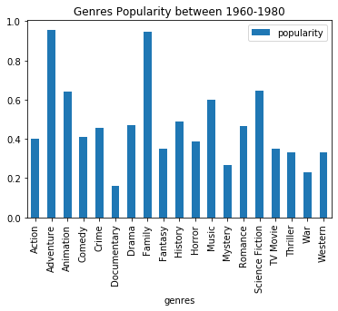

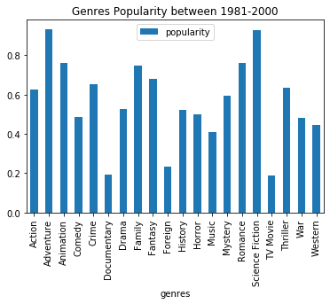

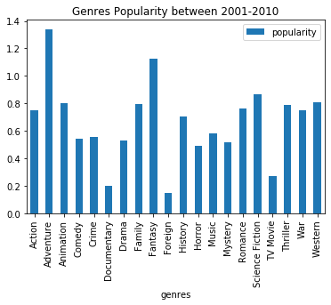

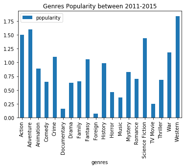

```python
# plotting genres popularity for different year duration

%matplotlib inline

df_1960_80.plot(x='genres', y='popularity', kind = 'bar', title = 'Genres Popularity between 1960-1980')
df_1981_2000.plot(x='genres', y='popularity', kind = 'bar', title = 'Genres Popularity between 1981-2000')
df_2001_2010.plot(x='genres', y='popularity', kind = 'bar', title = 'Genres Popularity between 2001-2010')
df_2011_2015.plot(x='genres', y='popularity', kind = 'bar', title = 'Genres Popularity between 2011-2015')
```

### Research Question 2 (What kinds of properties are associated with movies that have high revenues ?)

#### -- The approach is to explore the effect of different properties related to movies on the revenue

```python
mov_df.describe()
```

|  | id | popularity | budget | revenue | runtime | vote_count | vote_average | release_year | budget_adj | revenue_adj |
| --- | --- | --- | --- | --- | --- | --- | --- | --- | --- | --- |
| count | 10812.000000 | 10812.000000 | 1.081200e+04 | 1.081200e+04 | 10812.000000 | 10812.000000 | 10812.000000 | 10812.000000 | 1.081200e+04 | 1.081200e+04 |
| mean | 65558.945523 | 0.648730 | 1.469493e+07 | 4.002213e+07 | 102.421846 | 218.369404 | 5.975379 | 2001.288938 | 1.763476e+07 | 5.162081e+07 |
| std | 91662.645876 | 1.001976 | 3.097338e+07 | 1.172614e+08 | 30.871363 | 576.886018 | 0.934122 | 12.819746 | 3.436996e+07 | 1.449476e+08 |
| min | 5.000000 | 0.000065 | 0.000000e+00 | 0.000000e+00 | 2.000000 | 10.000000 | 1.500000 | 1960.000000 | 0.000000e+00 | 0.000000e+00 |
| 25% | 10576.750000 | 0.209045 | 0.000000e+00 | 0.000000e+00 | 90.000000 | 17.000000 | 5.400000 | 1995.000000 | 0.000000e+00 | 0.000000e+00 |
| 50% | 20500.500000 | 0.385298 | 0.000000e+00 | 0.000000e+00 | 99.000000 | 38.000000 | 6.000000 | 2006.000000 | 0.000000e+00 | 0.000000e+00 |
| 75% | 74725.250000 | 0.716608 | 1.550000e+07 | 2.439961e+07 | 112.000000 | 146.000000 | 6.600000 | 2011.000000 | 2.100797e+07 | 3.403177e+07 |
| max | 417859.000000 | 32.985763 | 4.250000e+08 | 2.781506e+09 | 900.000000 | 9767.000000 | 9.200000 | 2015.000000 | 4.250000e+08 | 2.827124e+09 |

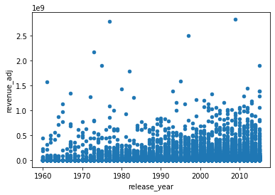

```python
mov_df.plot(x='release_year', y='revenue_adj', kind='scatter')
```

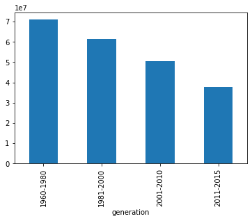

```python
mov_df.groupby('generation')['revenue_adj'].mean().plot(kind='bar')
```

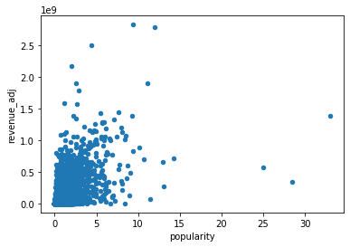

```python
mov_df.plot(x='popularity', y='revenue_adj', kind='scatter')
```

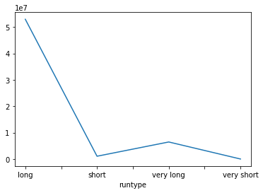

```python
mov_df.groupby('runtype')['revenue_adj'].mean().plot()
```

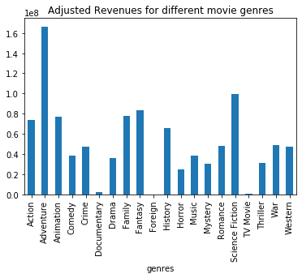

```python
mov_df.groupby('genres')['revenue_adj'].mean().plot(kind='bar', title='Adjusted Revenues for different movie genres')
```

### Research Question 3 (What is the impact of runtime on popularity?)

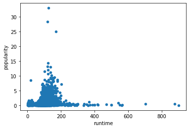

```python
mov_df.plot(x='runtime', y='popularity', kind='scatter')
```

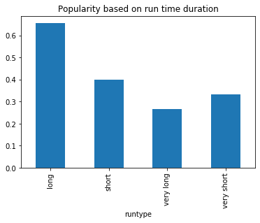

```python
mov_df.groupby('runtype')['popularity'].mean().plot(kind='bar', title='Popularity based on run time duration')
```

## Conclusions

### Research Question 1 (Which genres are most popular from year to year?)

>

> Different Genres have gained popularity from time to time, I have divided the most popular Genres for '4' time periods -:
> 1. Between 1960-1980 - 'Adventure' and 'Family' were the most popular genres
> 2. Between 1981-2000 - 'Adventure' was still popular but 'Science Fiction' gained poplarity
> 3. Between 2001-2010 - Along with 'Adventure', 'Fantasy' gained popularity
> 4. Between 2011-2015 - 'Western' gained popularity along with other genres like 'Action', 'Adventure' being popular

### Research Question 2 (What kinds of properties are associated with movies that have high revenues ?)

>

> In this I have explored effect of '4' different parameters on Adjusted Revenues i.e. 'Release Year', 'Popularity', 'Run Type'(i.e. Run time duration) and 'Genres'.
> 1. 'Release Year' - The plots shows the adjusted revenues has decreased over time.
> 2. 'Popularity' - Movies with 'Maximum' Popularity does not have the 'Maximum' revenues
> 3. 'Run Type' - Movies with Long duration(50-299) bring in the highest revenues, 'Very Short' movies has minimum revenues
> 4. 'Genres' - 'Adventure' genre has the highest revenue followed by 'Science Fiction'

### Research Question 3 (What is the impact of runtime on popularity?)

>

> As shown by the bar graph, Movies with long duration(50-299) are the most poular movie type among the fans, followed by short movies type.